# leprechaun shiny app-packages

### Setup

In this section I’ll cover the initial files in the new `leprechaun` application.

#### `R/`

- The `R/` folder contents are below:
  - Some of these files should look familiar (`R/ui.R`, `R/server.R`, and `R/run.R`)

  ```bash
          └── R/
              ├── _disable_autoload.R
              ├── assets.R
              ├── input-handlers.R
              ├── leprechaun-utils.R
              ├── run.R
              ├── server.R
              ├── ui.R
              └── zzz.R
  ```

- The initial application files are created using [`leprechaun::scaffold()`](https://leprechaun.opifex.org/#/reference/scaffold), which takes the following options as function arguments:
  - `ui` controls the application layout (can be `"fluidPage"` or `"navbarPage"`, defaults to `"navbarPage"`)
  - `bs_version` Bootstrap version (“*If shiny > 1.6 is installed defaults to version 5, otherwise version 4”* )
  - `overwrite`: Overwrite all files?
- `assets.R`: contains the `serveAssets()` function, which will identify the modules using CSS or JavaScript and create `dependencies`, a list of metadata on the app. If you run the function after initially building your `leprechaun` app, you’ll see the following:

  *Click on Code to view code in `R/assets.R`*

  ```r
  #' Dependencies
  #'
  #' @param modules JavaScript files names that require
  #' the `type = module`.
  #' @importFrom htmltools htmlDependency
  #'
  #' @keywords internal
  serveAssets <- function(modules = NULL) {
    # JavaScript files
    javascript <- list.files(
      system.file(package = "myLeprechaunApp"),
      recursive = TRUE,
      pattern = ".js$"
    )

    modules <- get_modules(javascript, modules)
    javascript <- remove_modules(javascript, modules)

    # CSS files
    css <- list.files(
      system.file(package = "myLeprechaunApp"),
      recursive = TRUE,
      pattern = ".css$"
    )

    # so dependency processes correctly
    names(css) <- rep("file", length(css))
    names(javascript) <- rep("file", length(javascript))

    # serve dependencies
    dependencies <- list()

    standard <- htmlDependency(
      "myLeprechaunApp",
      version = utils::packageVersion("myLeprechaunApp"),
      package = "myLeprechaunApp",
      src = ".",
      script = javascript,
      stylesheet = css
    )
    dependencies <- append(dependencies, list(standard))

    if (!is.null(modules)) {
      modules <- htmlDependency(
        "myLeprechaunApp-modules",
        version = utils::packageVersion("myLeprechaunApp"),
        package = "myLeprechaunApp",
        src = ".",
        script = modules,
        meta = list(type = "module")
      )
      dependencies <- append(dependencies, list(modules))
    }

    return(dependencies)
  }

  #' Module
  #'
  #' Retrieve and add modules from a vector of files.
  #'
  #' @param files JavaScript files
  #' @param modules JavaScript files names that require
  #' the `type = module`.
  #' @importFrom htmltools htmlDependency
  #'
  #' @keywords internal
  #' @name js-modules
  remove_modules <- function(files, modules) {
    if (is.null(modules)) {
      return(files)
    }

    # make pattern
    pattern <- collapse_files(modules)

    # remove modules
    files[!grepl(pattern, files)]
  }

  #' @rdname js-modules
  #' @keywords internal
  get_modules <- function(files, modules) {
    if (is.null(modules)) {
      return(NULL)
    }

    # make pattern
    pattern <- collapse_files(modules)

    # remove modules
    files[grepl(pattern, files)]
  }

  # collapse files into a pattern
  collapse_files <- function(files) {
    pattern <- paste0(files, collapse = "$|")
    paste0(pattern, "$")
  }
  ```

  ```r
  serveAssets()
  ```

  *Click on Code to view the initial output from `serveAssets()`*

  ```bash
  [[1]]
  List of 10
   $ name      : chr "myLeprechaunApp"
   $ version   : chr "0.0.0.9000"
   $ src       :List of 1
    ..$ file: chr "."
   $ meta      : NULL
   $ script    : Named chr(0)
    ..- attr(*, "names")= chr(0)
   $ stylesheet: Named chr(0)
    ..- attr(*, "names")= chr(0)
   $ head      : NULL
   $ attachment: NULL
   $ package   : chr "myLeprechaunApp"
   $ all_files : logi TRUE
   - attr(*, "class")= chr "html_dependency"
  ```

- `_disable_autoload.R` is a way to disable the `shiny::loadSupport()` function. By default, shiny will load *any top-level supporting `.R` files in the `R/` directory adjacent to the `app.R`/`server.R`/`ui.R` files.*
- `input-handlers.R`:

  *Click on Code to view code in `R/input-handlers.R`*

  ```r
  #' Input Dataframe
  #'
  #' Converts the input received from the WebSocket
  #' to a data.frame.
  #'
  #' @param data Input data received from WebSocket.
  #'
  #' @keywords internal
  leprechaun_handler_df <- function(data){
      do.call("rbind", lapply(data))
  }

  #' Input List
  #'
  #' Forces the input received from the WebSocket
  #' to a list. This should really not be needed as
  #' it is handled like so by default.
  #'
  #' @param data Input data received from WebSocket.
  #'
  #' @keywords internal
  leprechaun_handler_list <- function(data){
      return(data)
  }

  .onAttach <- function(...) {
      shiny::registerInputHandler(
          "myLeprechaunApp.list",
          leprechaun_handler_list,
          force = TRUE
      )

      shiny::registerInputHandler(
          "myLeprechaunApp.df",
          leprechaun_handler_df,
          force = TRUE
      )
  }
  ```

- `leprechaun-utils.R` initially contains the `make_send_message()` function (which is used in the `R/server.R` below).

  *Click on Code to view code in `R/leprechaun-utils.R`*

  ```r
  #' Create a Helper to Send Messages
  #'
  #' Create a function to send custom messages to the front-end,
  #' this function makes it such that the namespace is carried
  #' along.
  #' The namespace is appended as `ns`.
  #' The namespace with the optional hyphen is
  #' included as `ns2`.
  #'
  #' @param session Shiny session to derive namespace
  #' @param prefix A prefix to add to all types.
  #' Note that the prefix is followed by a hyphen `-`.
  #'
  #' @examples
  #' \dontrun{
  #' send_message <- make_send_message(session)
  #' send_message("do-sth")
  #' send_message("do-sth-else", x = 1)
  #'
  #' # with prefix
  #' send_message <- make_send_message(session, prefix = "PREFIX")
  #'
  #' # this sends a message of type:
  #' # PREFIX-so-th
  #' send_message("do-sth")
  #' }
  #'
  #' @noRd
  #' @keywords internal
  make_send_message <- function(session, prefix = NULL) {
    ns <- session$ns(NULL)

    ns2 <- ns
    if (length(ns) > 0 && ns != "") {
      ns2 <- paste0(ns2, "-")
    }

    function(msgId, ...) {
      if (!is.null(prefix)) {
        msgId <- sprintf("%s-%s", prefix, msgId)
      }

      session$sendCustomMessage(
        msgId,
        list(
          ns = ns,
          ns2 = ns2,
          ...
        )
      )
    }
  }
  ```

- `run.R` contains functions for running the production (`run()`) and development version of the application (`run_dev()`):

  *Click on Code to view code in `R/run.R`*

  ```r
  #' Run
  #'
  #' Run application
  #'
  #' @param ... Additional parameters to pass to [shiny::shinyApp].
  #'
  #' @importFrom shiny shinyApp
  #'
  #' @export
  run <- function(...){
      shinyApp(
          ui = ui,
          server = server,
          ...
      )
  }

  #' Run Development
  #'
  #' Runs the development version which includes
  #' the build step.
  #'
  #' @keywords internal
  run_dev <- function(){
      file <- system.file("run/app.R", package = "myLeprechaunApp")
      shiny::shinyAppFile(file)
  }
  ```

- `server.R` by default creates `send_message` with `make_send_message(session)` (see `R/leprechaun-utils.R` above).

  *Click on Code to view code in `R/server.R`*

  ```r
  #' Server
  #'
  #' Core server function.
  #'
  #' @param input,output Input and output list objects
  #' containing said registered inputs and outputs.
  #' @param session Shiny session.
  #'
  #' @noRd
  #' @keywords internal
  server <- function(input, output, session){
      send_message <- make_send_message(session)
  }
  ```

- `ui.R` holds the `ui()` and `assets()` functions. `assets()` loads the resources called in the `R/assets.R` file (see `serveAssets()` function above).

  *Click on Code to view code in `ui()`*

  ```r
  #' Shiny UI
  #'
  #' Core UI of package.
  #'
  #' @param req The request object.
  #'
  #' @import shiny
  #' @importFrom bslib bs_theme
  #'
  #' @keywords internal
  ui <- function(req) {
      fluidPage(
          theme = bs_theme(version = 5),
          assets(),
          h1("myLeprechaunApp")
      )
  }
  ```

  *Click on Code to view code in `assets()`*

  ```r
  #' Assets
  #'
  #' Includes all assets.
  #' This is a convenience function that wraps
  #' [serveAssets] and allows easily adding additional
  #' remote dependencies (e.g.: CDN) should there be any.
  #'
  #' @importFrom shiny tags
  #'
  #' @keywords internal
  assets <- function() {
      list(
          serveAssets(), # base assets (assets.R)
          tags$head(
              # Place any additional depdendencies here
              # e.g.: CDN
          )
      )
  }
  ```

- `zzz.R` contains [`shiny`’s `addResourcePath()` function](https://shiny.rstudio.com/reference/shiny/1.0.1/addresourcepath) for adding images to the application (in `inst/img/`)

  *Click on Code to view code in `R/zzz.R`*

  ```r
  .onLoad <- function(...){
      shiny::addResourcePath(
          "img",
          system.file("img", package = "myLeprechaunApp")
      )
  }
  ```

#### `inst/run/app.R`

- `app.R` contains a file that *looks* like it would be used to run the application, but it’s not. This file contains a call to `leprechaun::build()`, then `pkgload::load_all()`.

  *Click on Code to view code in `inst/run/app.R`*

  ```r
  # do not deploy from this file
  # see leprechaun::add_app_file()
  leprechaun::build()

  pkgload::load_all(
      path = "../../",
      reset = TRUE,
      helpers = FALSE
  )

  run()
  ```

  - This file is not run directly (check `leprechaun::add_app_file()`):

## Build

Building `leprechaun` apps is similar to `golem`/R packages. New code is placed in the R/ folder, and application resources (CSS, SASS, JavaScript files) are added using one of the `leprechaun::use_*` functions:

- [`use_sass()`](https://leprechaun.opifex.org/#/reference/use_sass)
- [`use_html_utils()`](https://leprechaun.opifex.org/#/reference/use_html_utils)
- [`use_endpoints_utils()`](https://leprechaun.opifex.org/#/reference/use_endpoints_utils)
- [`use_js_utils()`](https://leprechaun.opifex.org/#/reference/use_js_utils)

More assets can be added using the [`leprechaun::use_packer()`](https://leprechaun.opifex.org/#/examples/basic#javascript) function.

### Develop

The [`leprechaun::scaffold()`](https://leprechaun.opifex.org/#/reference/scaffold) defaults to a `navbarPage()`, but I’ll switch to a `fluidPage()` for this example.

After `devtools::load_all()` and `devtools::document()`, restarting and loading the package, I can run the application with `run()`.

[figure not shown]

Figure 2: Initial `run()`

#### `add_module()`

Creating modules is simple with [`leprechaun::add_module()`](https://leprechaun.opifex.org/#/reference/add_module).

- The initial UI module:

  ```r
  leprechaun::add_module("var_input")
  ```

  ```bash
  ✔ Creating R/module_var_input.R
  ```

  - Similar to `golem`, this creates functions for the UI and server portions of the module.

  ```r
  #' var_input UI
  #'
  #' @param id Unique id for module instance.
  #'
  #' @keywords internal
  var_inputUI <- function(id){
      ns <- NS(id)

      tagList(
          h2("var_input"),

      )
  }
  ```

  - The initial server module:

  ```r
  #' var_input Server
  #'
  #' @param id Unique id for module instance.
  #'
  #' @keywords internal
  var_input_server <- function(id){
      moduleServer(
          id,
          function(
              input,
              output,
              session
              ){

                  ns <- session$ns
                  send_message <- make_send_message(session)

                  # your code here
          }
      )
  }

  # UI
  # var_inputUI('id')

  # server
  # var_input_server('id')
  ```

  - Note the `send_message <- make_send_message(session)` in `var_input_server()`. I will show how this is used in the JavaScript section below.

**TipTip: `@keywords internal`**

The module contents are similar to `golem`, but instead of using the `@noRd` tag, these functions include `@keywords internal` (which can be used to [document your package](https://roxygen2.r-lib.org/articles/rd-other.html?q=@keywords#packages)).

- In order to this, run `usethis::use_package_doc()` and a script will be created in `R/` with the following contents:

```
'_PACKAGE'

## usethis namespace: start
## usethis namespace: end
NULL
```

The code for the `var_input` and `plot_display` modules are below.

- The `R/module_var_input.R` file:

  *Click on Code to view code in `R/module_var_input.R`*

  ```r
  #' var_input UI
  #'
  #' @param id Unique id for module instance.
  #'
  #' @keywords internal
  #'
  #' @return shiny UI module
  #' @export var_inputUI
  #'
  #' @description A shiny Module.
  #'
  #' @importFrom shiny NS tagList selectInput
  #' @importFrom shiny sliderInput textInput
  var_inputUI <- function(id){
      ns <- shiny::NS(id)
      shiny::tagList(
      shiny::selectInput(
        inputId = ns("y"),
        label = "Y-axis:",
        choices = c(
          "IMDB rating" = "imdb_rating",
          "IMDB number of votes" = "imdb_num_votes",
          "Critics Score" = "critics_score",
          "Audience Score" = "audience_score",
          "Runtime" = "runtime"
        ),
        selected = "audience_score"
      ),
      shiny::selectInput(
        inputId = ns("x"),
        label = "X-axis:",
        choices = c(
          "IMDB rating" = "imdb_rating",
          "IMDB number of votes" = "imdb_num_votes",
          "Critics Score" = "critics_score",
          "Audience Score" = "audience_score",
          "Runtime" = "runtime"
        ),
        selected = "imdb_rating"
      ),
      shiny::selectInput(
        inputId = ns("z"),
        label = "Color by:",
        choices = c(
          "Title Type" = "title_type",
          "Genre" = "genre",
          "MPAA Rating" = "mpaa_rating",
          "Critics Rating" = "critics_rating",
          "Audience Rating" = "audience_rating"
        ),
        selected = "mpaa_rating"
      ),
      shiny::sliderInput(
        inputId = ns("alpha"),
        label = "Alpha:",
        min = 0, max = 1, step = 0.1,
        value = 0.5
      ),
      shiny::sliderInput(
        inputId = ns("size"),
        label = "Size:",
        min = 0, max = 5,
        value = 2
      ),
      shiny::textInput(
        inputId = ns("plot_title"),
        label = "Plot title",
        placeholder = "Enter plot title"
      )
      )
  }

  #' var_input Server
  #'
  #' @param id Unique id for module instance.
  #'
  #' @keywords internal
  #'
  #' @return shiny server module
  #' @export var_input_server
  #'
  #' @importFrom shiny NS moduleServer reactive
  var_input_server <- function(id){
      moduleServer(
          id,
          function(
              input,
              output,
              session
              ){

                  ns <- session$ns
                  send_message <- make_send_message(session)

                  # your code here
      return(
        list(
          "x" = shiny::reactive({
            input$x
          }),
          "y" = shiny::reactive({
            input$y
          }),
          "z" = shiny::reactive({
            input$z
          }),
          "alpha" = shiny::reactive({
            input$alpha
          }),
          "size" = shiny::reactive({
            input$size
          }),
          "plot_title" = shiny::reactive({
            input$plot_title
          })
          )
        )
          }
      )
  }

  # UI
  # var_inputUI('id')

  # server
  # var_input_server('id')
  ```

- The `R/module_plot_display.R` file:
  - My `plot_dispay` module collects the data from var_input and creates the plot with the custom `point_plot()` function:

  *Click on Code to view code in `R/module_plot_display.R`*

  ```r
  #' plot_display UI
  #'
  #' @param id Unique id for module instance.
  #'
  #' @return shiny UI module
  #' @export plot_displayUI
  #'
  #' @description A shiny Module.
  #'
  #' @importFrom shiny NS tagList tags
  #' @importFrom shiny plotOutput
  plot_displayUI <- function(id){
      ns <- shiny::NS(id)
      shiny::tagList(
      shiny::tags$br(),
      shiny::tags$blockquote(
        shiny::tags$em(
          shiny::tags$h6(
            "The code for this application comes from the ",
            shiny::tags$a("Building web applications with Shiny",
              href = "https://rstudio-education.github.io/shiny-course/"
            ),
            "tutorial"
          )
        )
      ),
      shiny::plotOutput(outputId = ns("scatterplot"))
      )
  }

                  # your code here
      movies <- myLeprechaunApp::movies

      inputs <- shiny::reactive({
        plot_title <- tools::toTitleCase(var_inputs$plot_title())
        list(
          x = var_inputs$x(),
          y = var_inputs$y(),
          z = var_inputs$z(),
          alpha = var_inputs$alpha(),
          size = var_inputs$size(),
          plot_title = plot_title
        )
      })

      output$scatterplot <- shiny::renderPlot({
        plot <- point_plot(
          df = movies,
          x_var = inputs()$x,
          y_var = inputs()$y,
          col_var = inputs()$z,
          alpha_var = inputs()$alpha,
          size_var = inputs()$size
        )
        plot +
          ggplot2::labs(
            title = inputs()$plot_title,
              x = stringr::str_replace_all(
                    tools::toTitleCase(
                        inputs()$x),
                      "_",
                    " "),
              y = stringr::str_replace_all(
                    tools::toTitleCase(
                        inputs()$y),
                    "_",
                  " ")) +
          ggplot2::theme_minimal() +
          ggplot2::theme(legend.position = "bottom")
      })
          }
      )
  }

  # UI
  # plot_displayUI('id')

  # server
  # plot_display_server('id')
  ```

After creating the modules, adding them to the UI (`R/ui.R`) and server (`R/server.R`) is straightforward.

- The `R/ui.R` file:

  ```r
  #' Shiny UI
  #'
  #' Core UI of package.
  #'
  #' @param req The request object.
  #'
  #' @import shiny
  #' @importFrom bslib bs_theme
  #'
  #' @keywords internal
  ui <- function(req) {
    fluidPage(
      theme = bs_theme(version = 5),
      assets(),
      h1("myLeprechaunApp"),
      # Begin new code -->
      shiny::sidebarLayout(
        shiny::sidebarPanel(
          var_inputUI("vars")
        ),
        shiny::mainPanel(
          plot_displayUI("plot")
        )
      )
      ## End new code <--
    )
  }
  ```

- The `R/server.R` file:
  - The server also has the `make_send_message()` function in it by default (more on that below).

  *Click on Code to view code in `R/server.R`*

  ```r
  #' Server
  #'
  #' Core server function.
  #'
  #' @param input,output Input and output list objects
  #' containing said registered inputs and outputs.
  #' @param session Shiny session.
  #'
  #' @noRd
  #' @keywords internal
  server <- function(input, output, session){

      send_message <- make_send_message(session)

    ## New code -->
     selected_vars <- var_input_server("vars")

     plot_display_server("plot", var_inputs = selected_vars)
     ## New code <--

  }
  ```

The other components of `myLeprechaunApp` were created using the standard `usethis` package development functions.

#### `use_data_raw()`

- the `movies` data was added to `inst/extdata` and loaded into the package with `usethis::use_data_raw()`

**NoteAdding data to a package**

After calling `usethis::use_data_raw('movies')`, I can use `system.file()` to locate the file with the following code in `data-raw/movies.R`:

```r
## code to prepare `movies` dataset goes here
pth <- system.file('extdata/movies.RData', package = 'myLeprechaunApp')
load(pth)
usethis::use_data(movies, overwrite = TRUE)
```

#### `use_r()`

- `usethis::use_r()` created `R/utils_plot_display.R` to hold the `point_plot()` function

  *Click on Code to view code in `R/utils_plot_display.R`*

  ```r
  #' Plot points (shiny)
  #'
  #' @param df input dataset (tibble or data.frame)
  #' @param x_var x variable
  #' @param y_var y variable
  #' @param col_var color variable
  #' @param alpha_var alpha value
  #' @param size_var size value
  #'
  #' @return plot object
  #' @export point_plot
  #'
  #' @importFrom ggplot2 ggplot aes geom_point
  #'
  #' @examples
  #' \donttest{
  #' load(
  #'   list.files(
  #'     system.file("extdata", package = "myLeprechaunApp"),
  #'    pattern = "movies",
  #'    full.names = TRUE)
  #'    )
  #' point_plot(df = movies,
  #'   x_var = "critics_score",
  #'   y_var = "imdb_rating",
  #'   col_var = "critics_rating",
  #'   alpha_var = 1/3,
  #'   size_var = 2)
  #' }
  point_plot <- function(df, x_var, y_var, col_var, alpha_var, size_var) {
      ggplot2::ggplot(data = df,
        ggplot2::aes(x = .data[[x_var]],
            y = .data[[y_var]],
            color = .data[[col_var]])) +
        ggplot2::geom_point(alpha = alpha_var, size = size_var)

  }
  ```

Now I can run `devtools::load_all()`, `devtools::document()`, restart and load the package, then `run()`

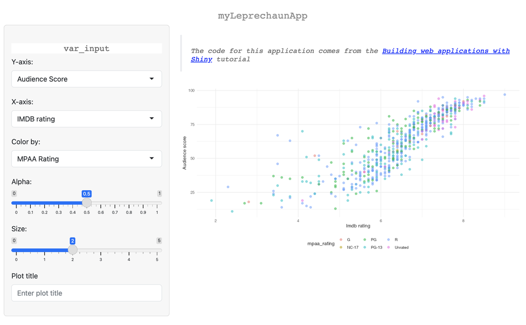

Figure 3: run `myLeprechaunApp`

#### `inst/`

`leprechaun` uses the `inst/` folder similar to the `golem` framework, but instead of only loading the files in `inst/app/www`, `leprechaun` apps include four sub-folders that are ready at application runtime.

##### `packer`

To demonstrate how the `make_send_message()` function works, I’ll walk through the [JavaScript example from the package website](https://leprechaun.opifex.org/#/examples/basic#javascript).

- Run `packer::scaffold_leprechaun()`

  ```r
  packer::scaffold_leprechaun()
  ```

  *Click on Code to view the output from `packer::scaffold_leprechaun()`*

  ```bash
  ── Scaffolding leprechaun ──────────────────────────────────────────────
  ✔ Initialiased npm
  ✔ webpack, webpack-cli, webpack-merge installed with scope "dev"
  ✔ Added npm scripts
  ✔ Created srcjs directory
  ✔ Created srcjs/config directory
  ✔ Created webpack config files

  ── Adding files to .gitignore and .Rbuildignore ──

  ✔ Setting active project to '/Users/mjfrigaard/projects/myLeprechaunApp'
  ✔ Adding '^srcjs$' to '.Rbuildignore'
  ✔ Adding '^node_modules$' to '.Rbuildignore'
  ✔ Adding '^package\\.json$' to '.Rbuildignore'
  ✔ Adding '^package-lock\\.json$' to '.Rbuildignore'
  ✔ Adding '^webpack\\.dev\\.js$' to '.Rbuildignore'
  ✔ Adding '^webpack\\.prod\\.js$' to '.Rbuildignore'
  ✔ Adding '^webpack\\.common\\.js$' to '.Rbuildignore'
  ✔ Adding 'node_modules' to '.gitignore'

  ── Scaffold built ──

  ℹ Run `bundle` to build the JavaScript files
  ℹ Run `leprechaun::use_packer()`
  ```

- Run `leprechaun::use_packer()`

  ```r
  leprechaun::use_packer()
  ```

  ```bash
  ✔ Creating inst/dev/packer.R
  ✔ Adding 'packer' to Suggests in DESCRIPTION
  ! This requires `leprechaun::build()` or the `leprechaun::build_roclet`
  ```

- Run `leprechaun::build()`

  ```r
  leprechaun::build()
  ```

  ```bash
  ✔ Running packer.R
  ✔ Bundled
  ```

Now I can see what new files have been added to the package/app.

- In the `inst/dev/` folder:
  - I can see the `packer.R` file has been added

  ```bash
  inst/dev/
        └── packer.R

  1 directory, 1 file
  ```

  *Click on Code to view the output from `packer.R`*

  ```bash
  #' Bundle for Prod
  #'
  #' Bundles packer using packer.
  packer_bundle <- function(){
      has_packer <- requireNamespace("packer", quietly = TRUE)

      if(!has_packer){
          warning(
              "Requires `packer` package: `install.packages('packer')`\n",
              "Skipping.",
              call. = FALSE
          )
          return()
      }

      packer::bundle()
  }

  packer_bundle()
  ```

- In the `srcjs/` folder:
  - I can see how `modules/message.js` and `index.js` create the alert with `Shiny.addCustomMessageHandler`

  ```bash
  srcjs/
      ├── config
      │   ├── entry_points.json
      │   ├── externals.json
      │   ├── loaders.json
      │   ├── misc.json
      │   └── output_path.json
      ├── index.js
      └── modules
          └── message.js
  ```

  *The JavaScript in `modules/message.js` and `index.js`*

  ```javascript
  // srcjs/modules/message.js
  export const message = (msg) => {
    alert(msg);
  }
  // srcjs/index.js
  import { message } from './modules/message.js';
  import 'shiny';

  // In shiny server use:
  // session$sendCustomMessage('show-packer', 'hello packer!')
  Shiny.addCustomMessageHandler('show-packer', (msg) => {
    message(msg.text);
  })
  ```

To use the JS message scripts in `srcjs/`, I add the following to `R/server.R`:

- In `R/server.R`

  ```r
      send_message <- make_send_message(session)
      send_message("show-packer",
                    text = "this is a message from your server()")
  ```

After running `devtools::load_all()` and `devtools::document()`, the application loads with an alert:

[figure not shown]

Figure 4: `send_message()`

I can also include messages from modules.

- In `R/module_plot_display.R`

  ```r
          send_message <- make_send_message(session)
          send_message("show-packer",
            text = "this is a message from your plot_display module")
  ```

[figure not shown]

Figure 5: `send_message()` (module)

Read more about sending JavaScript messages [here on the shiny website.](https://shiny.rstudio.com/articles/js-send-message.html)

##### `img/`

I’ll demonstrate how to use the `inst/` folder by adding an image to the application.

- Assume I want to add `leprechaun.jpg` to my UI. I start by adding the file to `inst/img/`:

  ```bash
  inst/
    └── img/
         └── leprechaun.jpg <- new image file!
  ```

- Then I add the `img/` path to the code to UI:

  ```r
  ui <- function(req) {
    fluidPage(
      theme = bs_theme(version = 5),
      assets(),
      h1("myLeprechaunApp"),
      shiny::sidebarLayout(
        shiny::sidebarPanel(
          var_inputUI("vars")
        ),
        shiny::mainPanel(
          # new image
          shiny::tags$img(src = "img/leprechaun.jpg"),
          plot_displayUI("plot")
        )
      )
    )
  }
  ```

Once again, run `devtools::load_all()` and `devtools::document()`, restarting and loading the package, then run the application with `run()`

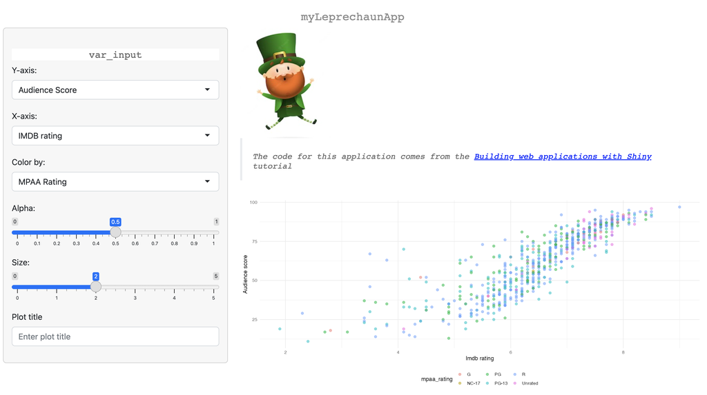

Figure 6: Adding images to `inst/img/`

##### `Sass`

`leprechaun` also has helper functions for adding additional resources (or *assets*) to an application. I’ll work through the [SASS example from the website](https://leprechaun.opifex.org/#/examples/basic#sass) below.

To add a Sass file, I can use [`leprechaun`’s `use_sass()` function](https://leprechaun.opifex.org/#/reference/use_sass).

- Run `leprechaun::use_sass()` (no arguments):

  ```r
  leprechaun::use_sass()
  ```

  - This will add files to `assets/` and `dev/` and I see the following messages:

  ```bash
  ✔ Creating scss
  ✔ Creating inst/dev/sass.R
  ✔ Adding 'sass' to Suggests in DESCRIPTION
  ✔ Adding '^scss$' to '.Rbuildignore'
  ! This requires `leprechaun::build()` or the `leprechaun::build_roclet`
  ```

  - Below are the new files in `inst/dev/` and `sass/`:

  ```bash
  inst/
      ├── scss/
      │   ├── _core.scss
      │   └── main.scss
      └── dev/
          └── sass.R
  ```

The `scss/` folder is created by [`leprechaun::use_sass()`](https://leprechaun.opifex.org/#/reference/use_sass), and it includes `_core.scss` and `main.scss`.

- `_core.scss`: the original file is below

  ```
  html{
      .error {
          color: red
      }
  }
  ```

- I will change the `color:` from `red` to green (`#38B44A`) using `$accent: #38B44A;`

  ```
  $accent: #38B44A;

  html{
      h1 {
          color: $accent;
      }
  }
  ```

- Then save this file and run [`leprechaun::build()`](https://leprechaun.opifex.org/#/reference/build)

  ```r
  leprechaun::build()
  ```

  ```bash
  ✔ Running packer.R
  ✔ Bundled
  ✔ Running sass.R
  ```

##### `dev/`

- The `inst/dev/sass.R` file contains a `sass_build()` function
  - `sass_build()` looks in the `scss/` folder for `main.scss` and creates the `inst/assets/style.min.css` file.

  *Click on Code to view code in `inst/dev/sass.R`*

  ```r
  #' Build CSS
  #'
  #' Build the sass
  sass_build <- function() {
    has_sass <- requireNamespace("sass", quietly = TRUE)

    if (!has_sass) {
      warning(
        "Requires `sass` package: `install.packages('sass')`\n",
        "Skipping.",
        call. = FALSE
      )
      return()
    }

    output <- sass::sass(
      sass::sass_file(
        "scss/main.scss"
      ),
      cache = NULL,
      options = sass::sass_options(
        output_style = "compressed"
      ),
      output = "inst/assets/style.min.css"
    )
    invisible(output)
  }

  sass_build()
  ```

Once again, I run `devtools::load_all()`, `devtools::document()`, install and restart, then load the package and `run()`

[figure not shown]

Figure 7: run `myLeprechaunApp` with new Sass

##### `assets/`

**How does `leprechaun::build()` work?**

The `assets/` folder contains the files generated by the `.R` scripts in the `dev/` folder.

- The contents of the `inst/dev/` folder:

  ```bash
  inst/dev/
        ├── packer.R
        └── sass.R

  1 directory, 2 files
  ```

- The contents of the `inst/assets/` folder:

  ```bash
  inst/assets/
          ├── index.js
          └── style.min.css

  1 directory, 2 files
  ```

- `inst/dev/sass.R` creates `inst/assets/style.min.css` and `inst/dev/packer.R` creates `inst/assets/index.js`

> *“Do not call this function from within the app. It helps build things, not run them.”* - [`build.md` guide](https://github.com/devOpifex/leprechaun/blob/1c8ef853d2fadc476926dd31424965fc19582d2f/docs/guide/build.md)

##### check `serveAssets()`

After running `leprechaun::use_sass()` and `leprechaun::build()` (which adds the `scss/` folder and the `.R` script in `inst/dev/`), I can re-check the `serveAssets()` function:

```r
serveAssets()
```

```bash
[[1]]
List of 10
 $ name      : chr "myLeprechaunApp"
 $ version   : chr "0.0.0.9000"
 $ src       :List of 1
  ..$ file: chr "."
 $ meta      : NULL
 $ script    : Named chr "assets/index.js"
  ..- attr(*, "names")= chr "file"
 $ stylesheet: Named chr [1:2] "assets/style.min.css" "html/R.css"
  ..- attr(*, "names")= chr [1:2] "file" "file"
 $ head      : NULL
 $ attachment: NULL
 $ package   : chr "myLeprechaunApp"
 $ all_files : logi TRUE
 - attr(*, "class")= chr "html_dependency"
```

This shows me `stylesheet` has been updated with `"assets/style.min.css"` and `script` has been updated with `"assets/index.js"` (these files are loaded into the application when it runs).

## Use

**Running `leprechaun` apps:**

When I initially create a new `leprechaun` package with `leprechaun::scaffold()`, I can run the application after a few quick steps:

1. `devtools::load_all()`
2. `devtools::document()`
3. Install and restart (optional)
4. `run()`

```r
devtools::load_all()
devtools::document()
# install and restart
library(myLeprechaunApp)
run()
```

[figure not shown]

Figure 8: run `myLeprechaunApp`

**NoteApp package scripts**

The output above shows that–unlike `golem` apps–`leprechaun` includes the functions in the `R/` folder as part of the `myLeprechaunApp` package.

**App files:**

- `R/`: After the initial setup, the [`R/` folder](https://github.com/mjfrigaard/shiny-app-setups/tree/main/myLeprechaunApp/R) of a leprechaun app contains standard `ui.R`, `server.R` files, as well as the `run.R` function for running the app.

  ```bash
  myLeprechaunApp/
        └── R/
            ├── _disable_autoload.R
            ├── assets.R
            ├── input-handlers.R
            ├── leprechaun-utils.R
            ├── run.R
            ├── server.R
            ├── ui.R
            └── zzz.R

        1 directory, 8 files
  ```

  - The additional files are specific to the `leprechaun` framework and workflow.

**Configure:**

`leprechaun` app configuration files use the [config](https://rstudio.github.io/config/articles/introduction.html) package (similar to `golem`). Unlike the `golem` package, it’s not assumed I’ll be using a `config.yml` file, but I can easily add one with [`leprechaun::use_config()`](https://leprechaun.opifex.org/#/guide/use#config).

- `use_config()` adds a `inst/config.yml` and `R/config.R`
- The default value in the `config.yml` files is `production: true`, which can be read using `config_read()` in `R/config.R`.

  ```r
  config_read()
  ```

  ```bash
  $production
  [1] TRUE
  ```

  - Values can be added to `inst/config.yml` using the [config file format](https://biostat.app.vumc.org/wiki/Main/YamlR), then the `CONFIG_FILE` can be set as [an environment variable](https://rstudio.github.io/config/articles/introduction.html#configurations)

**Workflow:**

- The [`inst/` folder](https://github.com/mjfrigaard/shiny-app-setups/tree/main/myLeprechaunApp/inst) contains various sub-folders for including external app resources (images, SASS, CSS, JavaScript, etc.).

  ```bash
  myLeprechaunApp/
      └── inst/
            ├── assets/
            ├── dev/
            ├── img/
            └── run/
                └── app.R

        5 directories, 1 file
  ```

- `leprechaun` apps are packages, so the `inst/` folders are available to the application at runtime (which I can find using `system.file()`).
  - Below I’ve passed the output from `system.file(".", package = "myLeprechaunApp")` to `fs::dir_tree()` to view it’s contents:

  ```bash
  ├── DESCRIPTION
  ├── INDEX
  ├── Meta/
  │   ├── Rd.rds
  │   ├── data.rds
  │   ├── features.rds
  │   ├── hsearch.rds
  │   ├── links.rds
  │   ├── nsInfo.rds
  │   └── package.rds
  ├── NAMESPACE
  ├── R/
  │   ├── myLeprechaunApp
  │   ├── myLeprechaunApp.rdb
  │   └── myLeprechaunApp.rdx
  ├── assets/
  │   ├── index.js
  │   └── style.min.css
  ├── data/
  │   ├── Rdata.rdb
  │   ├── Rdata.rds
  │   └── Rdata.rdx
  ├── dev/
  │   ├── packer.R
  │   └── sass.R
  ├── extdata/
  │   └── movies.RData
  ├── help/
  │   ├── AnIndex
  │   ├── aliases.rds
  │   ├── myLeprechaunApp.rdb
  │   ├── myLeprechaunApp.rdx
  │   └── paths.rds
  ├── html/
  │   ├── 00Index.html
  │   └── R.css
  ├── img/
  │   └── leprechaun.jpg
  └── run/
      └── app.R
  ```

  - I can see the `inst/` folders and files I’ve created are available to `myLeprechaunApp` at runtime:

  ```bash
  ├── DESCRIPTION
  ├── NAMESPACE
  ├── assets/
  │   ├── index.js
  │   └── style.min.css
  ├── dev/
  │   ├── packer.R
  │   └── sass.R
  ├── extdata/
  │   └── movies.RData
  └── img/
        └── leprechaun.jpg
  ```

## Recap

`leprechaun` delivers on its promise to be a ‘leaner and smaller’ version of `golem.` Most of the features in `golem` are also accessible in `leprechaun`. Including multiple `inst/` sub-folders makes adding assets to the application easier, and `leprechaun` has a long list of `use_*` functions for including Sass, CSS, HTML, and JavaScript. The package website has examples for getting started and adding multiple resources, but unfortunately the function **Reference** had limited documentation.

`leprechaun` doesn’t come with any testing functions, although this can be done using [`testthat`](https://testthat.r-lib.org/) and [`shinytest2`](https://rstudio.github.io/shinytest2/) (just as we would with a standard R package).

For the next (and last) post in this series, I will build a shiny application using the [`rhino` package](https://appsilon.github.io/rhino/).

[interactive chart not shown]